# Explore SF Salary Data

Michael Griffiths

Kaggle Datasets provides data on[San Francisco city employee data](https://www.kaggle.com/kaggle/sf-salaries).

For fun, let’s do some EDA.

```r
setwd(dir = '../sf_salaries/')
```

```r
library(dplyr)
library(RSQLite)
library(tidyr)
library(ggplot2)
library(readr)
library(stringr)
library(scales)
library(mixtools)
```

# Data

The files are in the `../output` subdirectory.

```r
list.files("output/")
```

```
## [1] "database.sqlite" "hashes.txt"      "Salaries.csv"
```

The two files are the SQLite database (`database.sqlite`), and the CSV file (`Salaries.csv`). In theory, these have exactly the same data.

Well, let’s check.

```r
# The CSV
data_csv <- read_csv("output/Salaries.csv", na=c("Not Provided"))
(glimpse(data_csv))
```

```
## Observations: 148654
## Variables:
## $ Id               (int) 1, 2, 3, 4, 5, 6, 7, 8, 9, 10, 11, 12, 13, 14...
## $ EmployeeName     (chr) "NATHANIEL FORD", "GARY JIMENEZ", "ALBERT PAR...
## $ JobTitle         (chr) "GENERAL MANAGER-METROPOLITAN TRANSIT AUTHORI...
## $ BasePay          (dbl) 167411.18, 155966.02, 212739.13, 77916.00, 13...
## $ OvertimePay      (dbl) 0.00, 245131.88, 106088.18, 56120.71, 9737.00...
## $ OtherPay         (dbl) 400184.25, 137811.38, 16452.60, 198306.90, 18...
## $ Benefits         (chr) "", "", "", "", "", "", "", "", "", "", "", "...
## $ TotalPay         (dbl) 567595.4, 538909.3, 335279.9, 332343.6, 32637...
## $ TotalPayBenefits (dbl) 567595.4, 538909.3, 335279.9, 332343.6, 32637...
## $ Year             (int) 2011, 2011, 2011, 2011, 2011, 2011, 2011, 201...
## $ Notes            (chr) "", "", "", "", "", "", "", "", "", "", "", "...
## $ Agency           (chr) "San Francisco", "San Francisco", "San Franci...
## $ Status           (chr) "", "", "", "", "", "", "", "", "", "", "", "...
```

```r
# The database
db <- src_sqlite("output/database.sqlite")

# Get table list
# Preview tables
(glimpse(db %>% tbl("Salaries")))
```

```
## Observations: 148654
## Variables:
## $ Id               (int) 1, 2, 3, 4, 5, 6, 7, 8, 9, 10, 11, 12, 13, 14...
## $ EmployeeName     (chr) "NATHANIEL FORD", "GARY JIMENEZ", "ALBERT PAR...
## $ JobTitle         (chr) "GENERAL MANAGER-METROPOLITAN TRANSIT AUTHORI...
## $ BasePay          (dbl) 167411.18, 155966.02, 212739.13, 77916.00, 13...
## $ OvertimePay      (int) 0, 245131, 106088, 56120, 9737, 8601, 89062, ...
## $ OtherPay         (dbl) 400184.25, 137811.38, 16452.60, 198306.90, 18...
## $ Benefits         (chr) "", "", "", "", "", "", "", "", "", "", "", "...
## $ TotalPay         (dbl) 567595.4, 538909.3, 335279.9, 332343.6, 32637...
## $ TotalPayBenefits (dbl) 567595.4, 538909.3, 335279.9, 332343.6, 32637...
## $ Year             (int) 2011, 2011, 2011, 2011, 2011, 2011, 2011, 201...
## $ Notes            (chr) "", "", "", "", "", "", "", "", "", "", "", "...
## $ Agency           (chr) "San Francisco", "San Francisco", "San Franci...
## $ Status           (chr) "", "", "", "", "", "", "", "", "", "", "", "...
```

A quick visual estimation suggest that they’re very similar. A keen eye might see that in the CSV, field `OvertimePay` is inferred as `dbl`, but in the SQL database it’s coerced to `int`.

Of course - does that mean there are differences? If all the `OvertimePay` has zero cents, they should be.

```r
head(data_csv) == db %>% tbl("Salaries") %>% head
```

```
##        Id EmployeeName JobTitle BasePay OvertimePay OtherPay Benefits
## [1,] TRUE         TRUE     TRUE    TRUE        TRUE     TRUE     TRUE
## [2,] TRUE         TRUE     TRUE    TRUE       FALSE     TRUE     TRUE
## [3,] TRUE         TRUE     TRUE    TRUE       FALSE     TRUE     TRUE
## [4,] TRUE         TRUE     TRUE    TRUE       FALSE     TRUE     TRUE
## [5,] TRUE         TRUE     TRUE    TRUE        TRUE     TRUE     TRUE
## [6,] TRUE         TRUE     TRUE    TRUE        TRUE     TRUE     TRUE
##      TotalPay TotalPayBenefits Year Notes Agency Status
## [1,]     TRUE             TRUE TRUE  TRUE   TRUE   TRUE
## [2,]     TRUE             TRUE TRUE  TRUE   TRUE   TRUE
## [3,]     TRUE             TRUE TRUE  TRUE   TRUE   TRUE
## [4,]     TRUE             TRUE TRUE  TRUE   TRUE   TRUE
## [5,]     TRUE             TRUE TRUE  TRUE   TRUE   TRUE
## [6,]     TRUE             TRUE TRUE  TRUE   TRUE   TRUE
```

Well: nope, they’re not the same. The good news is that’s the only column that has any differences in the first 6 rows. We could dig a little deeper to identify more, but - we don’t need to.

Since the CSV file has more accurate information, it’s preferred. Let’s juse use that.

```r
data <- data_csv
```

# Exploratory Data Analysis

The first thing I’d like to know is what the variables look like.

## Non-Numeric Variables

For the non-numeric vars (like `Notes`) I’d like to know:

- How many unique vablues are there?
- What’s the relative frequency?

```r
non_numeric_vars <- names(data)[!sapply(data, is.numeric)]
data %>%
    select(one_of(non_numeric_vars)) %>%
    summarise_each(funs(unique_vars = length(unique(.))))
```

[output not shown]

It looks like `EmployeeName` has the most unique values - in fact, relatively few people share names (~25%).

However, why are there so many values for `Benefits`? What’s in that column?

```r
# No values in the first few rows -
(head(data$Benefits))
```

```
## [1] "" "" "" "" "" ""
```

```r
# So how about unique values?
(head(unique(data$Benefits)))
```

```
## [1] ""         "44430.12" "69810.19" "53102.29" "72047.88" "44438.25"
```

Those are all numbers!

That makes some sense - by default `dplyr` scans the first 50 rows to infer type. If there were no numbers in the first 50 rows `dplyr` would cast to string.

When does the first non-empty value of benefits occur?

```r
which.min(data$Benefits == "")
```

```
## [1] 36160
```

That’s quite a lot of empty rows!

Well, we can coerce to number.

```r
data <- data %>%
    mutate(Benefits = as.numeric(Benefits))

# Update the list of non-numeric vars
non_numeric_vars <- names(data)[!sapply(data, is.numeric)]
```

OK - so now that we have the refreshed list, let’s look at the combinations of unique values in `Notes`, `Agency`, and `Status`.

```r
data %>%
    group_by(Notes, Agency, Status) %>%
    summarise(Frequency = n())
```

```
## Source: local data frame [3 x 4]
## Groups: Notes, Agency
##
##   Notes        Agency Status Frequency
## 1       San Francisco           110535
## 2       San Francisco     FT     22334
## 3       San Francisco     PT     15785
```

So - `Notes` contains no information; `Agency` is all the same; and `Status` is blank for most users. That looks unreliable… surely the only two options are *Part Time* (`PT`) or *Full Time* (`FT`)?

For the moment let’s remove `Notes` and `Agency` since they don’t add any value. We’ll figure out `Status` later.

```r
data <- data %>%
    select(-Notes, -Agency)
```

### Job Title

I want to pay special attention to `JobTitle`. What information do we have?

Let’s look at the most frequent.

```r
data %>%
    group_by(JobTitle) %>%
    summarise(Frequency = n()) %>%
    arrange(desc(Frequency)) %>%
    head
```

```
## Source: local data frame [6 x 2]
##
##                       JobTitle Frequency
## 1             Transit Operator      7036
## 2                Special Nurse      4389
## 3             Registered Nurse      3736
## 4 Public Svc Aide-Public Works      2518
## 5             Police Officer 3      2421
## 6                    Custodian      2418
```

It looks like we could perhaps classify some of these, but that requires domain expertise (*Police Officer 3* is obviously Police, but do all Police job have Police in the title?)

How many job titles only occur once?

```r
data %>%
    group_by(JobTitle) %>%
    summarise(Frequency = n()) %>%
    mutate(OccursOnce = Frequency == 1) %>%
    group_by(OccursOnce) %>%
    summarise(Total = n())
```

```
## Source: local data frame [2 x 2]
##
##   OccursOnce Total
## 1      FALSE  1920
## 2       TRUE   239
```

OK, so most jobs occur more than once few times. What are some of the ones that occur only once?

```r
data %>%
    filter(!duplicated(JobTitle)) %>%
    head()
```

```
## Source: local data frame [6 x 11]
##
##   Id      EmployeeName                                       JobTitle
## 1  1    NATHANIEL FORD GENERAL MANAGER-METROPOLITAN TRANSIT AUTHORITY
## 2  2      GARY JIMENEZ                CAPTAIN III (POLICE DEPARTMENT)
## 3  4 CHRISTOPHER CHONG           WIRE ROPE CABLE MAINTENANCE MECHANIC
## 4  5   PATRICK GARDNER   DEPUTY CHIEF OF DEPARTMENT,(FIRE DEPARTMENT)
## 5  6    DAVID SULLIVAN                      ASSISTANT DEPUTY CHIEF II
## 6  7         ALSON LEE             BATTALION CHIEF, (FIRE DEPARTMENT)
## Variables not shown: BasePay (dbl), OvertimePay (dbl), OtherPay (dbl),
##   Benefits (dbl), TotalPay (dbl), TotalPayBenefits (dbl), Year (int),
##   Status (chr)
```

They look pretty senior. How does the pay compare to the people who share a title?

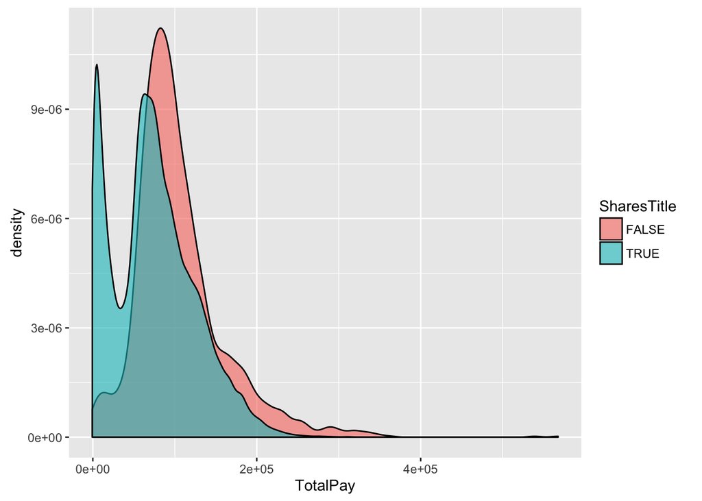

```r
data %>%
    mutate(SharesTitle = duplicated(JobTitle)) %>%
    ggplot(aes(x = TotalPay)) +
    geom_density(aes(fill = SharesTitle), alpha = 0.6)
```

Well, that’s interesting.

First of all: it looks like people who don’t share a title have somewhat higher pay - certainly in the right tail.

But why do so many people who *share* a title have such a high frequency of `TotalPay` at 0?

We obviously need to learn more about the numeric columns before embarking on this kind of analysis!

## Numeric Variables

Let’s look at a summary of the numeric vars.

```r
data %>%
    select(-one_of(non_numeric_vars)) %>%
    summary
```

```
##        Id            BasePay        OvertimePay           OtherPay
##  Min.   :     1   Min.   :  -166   Min.   :    -0.01   Min.   : -7058.6
##  1st Qu.: 37164   1st Qu.: 33588   1st Qu.:     0.00   1st Qu.:     0.0
##  Median : 74328   Median : 65007   Median :     0.00   Median :   811.3
##  Mean   : 74328   Mean   : 66325   Mean   :  5066.06   Mean   :  3648.8
##  3rd Qu.:111491   3rd Qu.: 94691   3rd Qu.:  4658.18   3rd Qu.:  4236.1
##  Max.   :148654   Max.   :319275   Max.   :245131.88   Max.   :400184.2
##                   NA's   :609      NA's   :4           NA's   :4
##     Benefits           TotalPay        TotalPayBenefits        Year
##  Min.   :  -33.89   Min.   :  -618.1   Min.   :  -618.1   Min.   :2011
##  1st Qu.:11535.40   1st Qu.: 36169.0   1st Qu.: 44065.7   1st Qu.:2012
##  Median :28628.62   Median : 71426.6   Median : 92404.1   Median :2013
##  Mean   :25007.89   Mean   : 74768.3   Mean   : 93692.6   Mean   :2013
##  3rd Qu.:35566.86   3rd Qu.:105839.1   3rd Qu.:132876.5   3rd Qu.:2014
##  Max.   :96570.66   Max.   :567595.4   Max.   :567595.4   Max.   :2014
##  NA's   :36163
```

A few interesting things -

- Some people have **negative** pay, . What on earth does that mean?
- `Year` looks like a factor indicating year.
- Does `Id` identify the row, or the employee?

Let’s take that in random order.

Does `Id` identify the employee?

```r
table(duplicated(data$Id))
```

```
##
##  FALSE
## 148654
```

Nope, it identifies the row. That’s frustrating - what if someone got a promotion in 2013? How can we track the change in their salary?

Who has negative pay?

```r
data %>%
    filter(TotalPay < 0)
```

```
## Source: local data frame [1 x 11]
##
##       Id EmployeeName                   JobTitle BasePay OvertimePay
## 1 148654    Joe Lopez Counselor, Log Cabin Ranch       0           0
## Variables not shown: OtherPay (dbl), Benefits (dbl), TotalPay (dbl),
##   TotalPayBenefits (dbl), Year (int), Status (chr)
```

OK, just one person. Perhaps he mis-stated an invoice in the previous year.

Who has pay of 0?

```r
data %>%
    filter(TotalPay == 0)
```

```
## Source: local data frame [368 x 11]
##
##       Id       EmployeeName                                   JobTitle
## 1  36157     PAULETTE ADAMS STATIONARY ENGINEER, WATER TREATMENT PLANT
## 2  36158      KAUKAB MOHSIN                           TRANSIT OPERATOR
## 3  36159 JOSEPHINE MCCREARY                                 MANAGER IV
## 4  70878      Roland Baylon                      Deputy Court Clerk II
## 5  70928   Felecia Phillips                           Registered Nurse
## 6  70929    Robert Giannini                                    Painter
## 7  70933         Nelly Kuan                  Senior Eligibility Worker
## 8  70934    William Mathews                  Transit Power Line Worker
## 9  70943      Gayle Mathews                 Senior Collections Officer
## 10 70957       Linda Carter                        Transit Car Cleaner
## ..   ...                ...                                        ...
## Variables not shown: BasePay (dbl), OvertimePay (dbl), OtherPay (dbl),
##   Benefits (dbl), TotalPay (dbl), TotalPayBenefits (dbl), Year (int),
##   Status (chr)
```

OK, so we have 368 people.

But - some of them are getting benefits. Perhaps they’re retired, on disability, or something else?

Alright - so now, how many people have pay between $0.00 and $100.00?

```r
data %>%
    filter(TotalPay > 0, TotalPay < 100)
```

```
## Source: local data frame [398 x 11]
##
##       Id        EmployeeName                                JobTitle
## 1  36071    CLARENCE JOHNSON    PUBLIC SERVICE AIDE-SPECIAL PROGRAMS
## 2  36072    RONALD TERASHIMA                   SENIOR DEPUTY SHERIFF
## 3  36073     LINDSAY PALAIMA                  PUBLIC SERVICE TRAINEE
## 4  36074        FIAMMA GIGER                  PUBLIC SERVICE TRAINEE
## 5  36075       CHERI COLLINS                  PSYCHIATRIC TECHNICIAN
## 6  36076  RUBEN HERNANDEZ JR                         GENERAL LABORER
## 7  36077         DEBRA TANIS                   FIRE RESCUE PARAMEDIC
## 8  36078     JOCELYN MADAMBA                           SPECIAL NURSE
## 9  36079     HARRY GOTWETTER                        TRANSIT OPERATOR
## 10 36080 MARIANNA BALQUIEDRA REPRESENTATIVE, HUMAN RIGHTS COMMISSION
## ..   ...                 ...                                     ...
## Variables not shown: BasePay (dbl), OvertimePay (dbl), OtherPay (dbl),
##   Benefits (dbl), TotalPay (dbl), TotalPayBenefits (dbl), Year (int),
##   Status (chr)
```

We have 398 people. This probably includes people who were paid for, say, an hour of their time.

Now: does the `Status` column have anything to do with this? Perhaps Full Time employees have more complete information.

## Job Status & Total Pay

Let’s take a quick look.

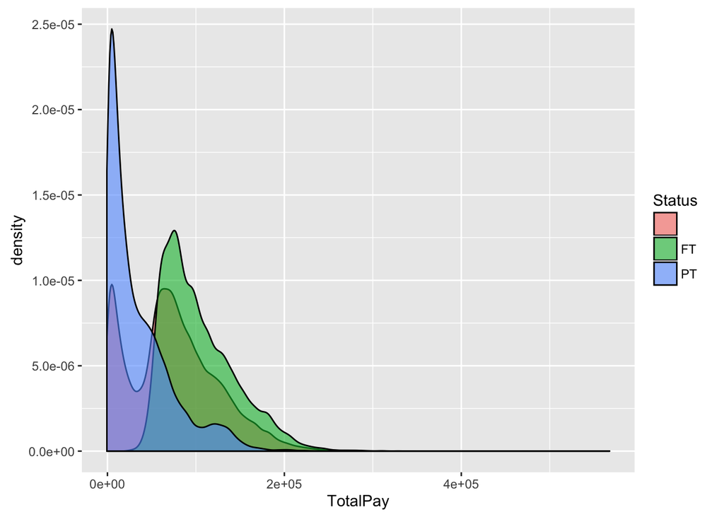

```r
data %>%
    ggplot(aes(x = TotalPay)) +
    geom_density(aes(fill = Status), alpha = 0.6)
```

Well, that makes a lot of sense. Part Time (`PT`) employees are compensated according to how much the city uses them - which is very little.

The story with blank `Status` is a little more complicated. Frankly, it looks like a lot of the blank entries should be full time; and some should be part time. We can see the graph split.

For now, let’s proceed by filtering down to `FT` employees. Later, we might want to do something with the missing values in the `Status` column (for instance, predict the right value).

# Analyzing Full Time Employees

First let’s create a dataset just for full time employees.

```r
ft <- data %>% filter(Status == "FT")
dim(ft)
```

```
## [1] 22334    11
```

OK. We have ~22,000 rows.

How does that break down by each year?

```r
ft %>%
    group_by(Year) %>%
    summarise(Frequency = n())
```

```
## Source: local data frame [1 x 2]
##
##   Year Frequency
## 1 2014     22334
```

They are **all** from 2014. Good to know.

That introduces the question about the blank `Status` rows. Perhaps values are only filled out for 2014? Let’s take a quick look before progressing.

```r
data %>%
    group_by(Year, Status) %>%
    summarise(Frequency = n()) %>%
    spread(Year, Frequency)
```

```
## Source: local data frame [3 x 5]
##
##   Status  2011  2012  2013  2014
## 1        36159 36766 37606     4
## 2     FT    NA    NA    NA 22334
## 3     PT    NA    NA    NA 15785
```

Well, that answers that question: **only** 2014 has people categorized, and even 2014 has 4 missing values (!). Who are they?

```r
data %>%
    filter(Status == "", Year == 2014)
```

```
## Source: local data frame [4 x 11]
##
##       Id EmployeeName     JobTitle BasePay OvertimePay OtherPay Benefits
## 1 148647 Not provided Not provided      NA          NA       NA       NA
## 2 148651 Not provided Not provided      NA          NA       NA       NA
## 3 148652 Not provided Not provided      NA          NA       NA       NA
## 4 148653 Not provided Not provided      NA          NA       NA       NA
## Variables not shown: TotalPay (dbl), TotalPayBenefits (dbl), Year (int),
##   Status (chr)
```

That’s… interesting. No names, and no pay?

Anyway: back to 2014 Full Time employees.

## Compensation

To start with, let’s look at compensation.

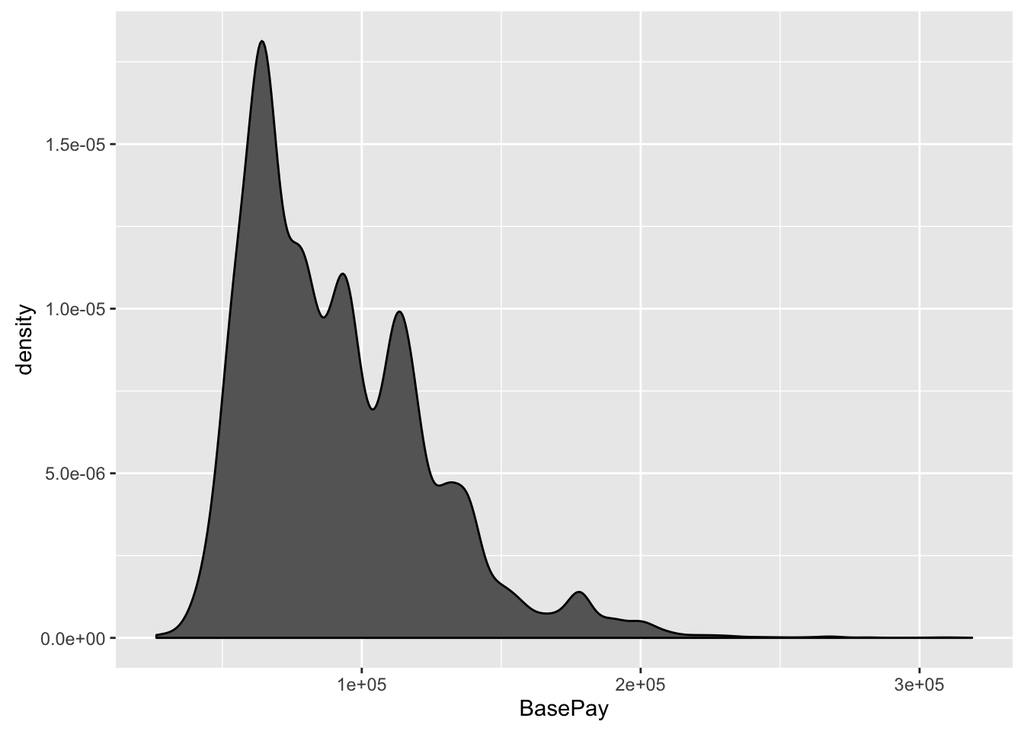

```r
ft %>%
    ggplot(aes(x = BasePay)) +
    geom_density(fill = "grey40")
```

It looks like we have a few spikes there - perhaps diferent types of jobs, or different levels?

What about overtime?

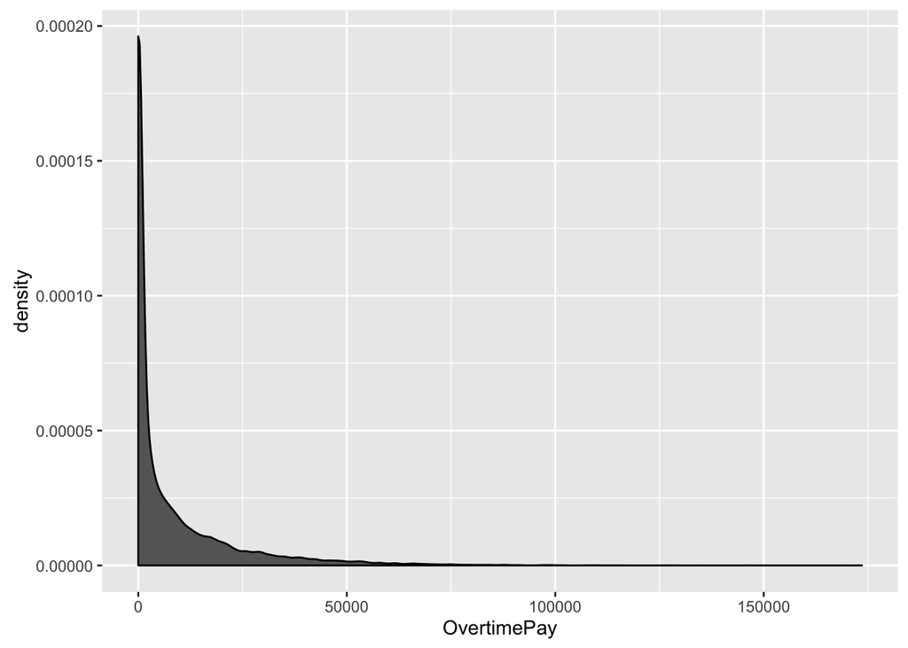

```r
ft %>%
    ggplot(aes(x = OvertimePay)) +
    geom_density(fill = "grey40")
```

That’s a …. pretty weird graph. Someone made over $150,000 in *overtime*? Really?

OK, so how about benefits.

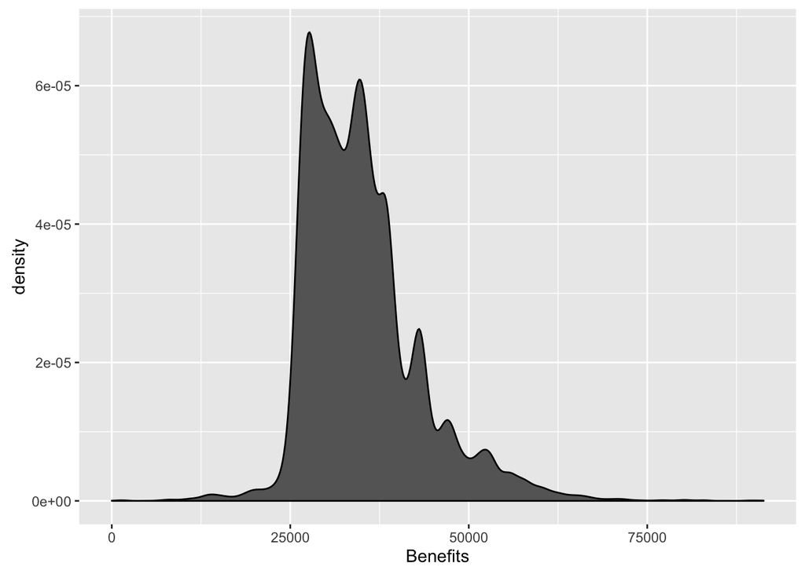

```r
ft %>%
    ggplot(aes(x = Benefits)) +
    geom_density(fill = "grey40")
```

## Job Titles

OK: there are ~22,000 people doing full time work. How many unique job titles?

```r
# How many
(length(unique(ft$JobTitle)))
```

```
## [1] 916
```

```r
# Quick previous
head(unique(ft$JobTitle))
```

```
## [1] "Asst Med Examiner"              "Chief of Police"
## [3] "Chief, Fire Department"         "Dept Head V"
## [5] "Executive Contract Employee"    "Battalion Chief, Fire Suppress"
```

I’d really like to categorize these somehow.

### Job Levels

Taking a quick look, it seems like some jobs end in a level (e.g. “2” or “I”). Let’s take a look.

```r
# Add to dataset
ft %>%
    mutate(level = str_extract(JobTitle, "(?<=\\s).$")) ->
    ft

# Subset down
ft %>%
    filter(!is.na(level)) ->
    jobs_with_levels

# Peek
(head(jobs_with_levels))
```

```
## Source: local data frame [6 x 12]
##
##       Id     EmployeeName       JobTitle  BasePay OvertimePay OtherPay
## 1 110538    John L Martin    Dept Head V 311298.5           0     0.00
## 2 110550 Barbara A Garcia    Dept Head V 279839.2           0  2164.54
## 3 110553 Denise A Schmitt Deputy Chief 3 268632.0           0  6192.08
## 4 110554      Lyn Tomioka Deputy Chief 3 268632.0           0  6192.08
## 5 110557    Charlie Orkes Deputy Chief 3 265729.5           0  6134.00
## 6 110559    Naomi M Kelly    Dept Head V 267914.0           0     0.00
## Variables not shown: Benefits (dbl), TotalPay (dbl), TotalPayBenefits
##   (dbl), Year (int), Status (chr), level (chr)
```

```r
jobs_with_levels %>%
    group_by(level) %>%
    summarise(People = n(), Titles = n_distinct(JobTitle))
```

```
## Source: local data frame [8 x 3]
##
##   level People Titles
## 1     1    745     64
## 2     2    990     44
## 3     3   1467     21
## 4     4     69      5
## 5     5     13      2
## 6     6      1      1
## 7     I    175     17
## 8     V    101      5
```

So, it looks like we have ~150 of the job titles and ~3,500 people that have levels.

Well - how do the levels compare?

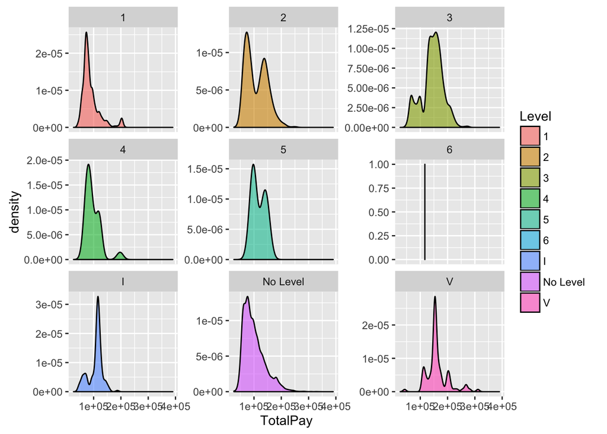

```r
ft %>%
    mutate(Level = ifelse(is.na(level), "No Level", level)) %>%
    ggplot(aes(x = TotalPay)) +
    geom_density(aes(fill = Level), alpha = 0.6) +
    facet_wrap(~Level, scales="free_y")
```

Unsurprisingly, it looks like 1 veers lower. Interesting to see 2, 3, 4, and 5 - there look to be at least two underlying distributions in each.

### Title Level

What about the information in “Asst” and “Associate”, etc?

Let’s look at the first word.

```r
ft %>%
    mutate(first_word = str_extract(JobTitle, "^.+?(?=\\s)")) %>%
    group_by(first_word) %>%
    summarise(frequency = n()) %>%
    arrange(desc(frequency))
```

```
## Source: local data frame [344 x 2]
##
##    first_word frequency
## 1          NA      2735
## 2     Transit      1862
## 3      Police      1355
## 4      Senior      1243
## 5      Deputy       710
## 6     Manager       681
## 7          IS       513
## 8         HSA       486
## 9    Sergeant       406
## 10     Health       383
## ..        ...       ...
```

The `NA` are introduced because the job title is only one word.

Unfortunately, the most frequent ones don’t pop out too well.

### Cheating: Job Type

The SQL script [SF Salaries by JobType](https://www.kaggle.com/mannychapman/d/kaggle/sf-salaries/sf-salaries-by-jobtype) created by mannychapman has some classification of job type. It’d be a shame to re-create work already done, so let’s re-implement here.

Since I’m a lazy man, I’d going to re-use the script almost as-is. We have that nice SQLite database - why not use it to retrieve IDs?

```r
query = "select  Id,
            case when jobtitle like '%fire%' then 'Fire'
            when jobtitle like '%police%' then 'Police'
            when jobtitle like '%sherif%' then 'Police'
            when jobtitle like '%probation%' then 'Police'
            when jobtitle like '%Sergeant%' then 'Police'


            when jobtitle like '%MTA%' then 'Transit'
            when jobtitle like '%transit%' then 'Transit'
            when jobtitle like '%anesth%' then 'Medical'
            when jobtitle like '%medical%' then 'Medical'
            when jobtitle like '%nurs%' then 'Medical'
            when jobtitle like '%health%' then 'Medical'
            when jobtitle like '%physician%' then 'Medical'
            when jobtitle like '%Orthopedic%' then 'Medical'

            when jobtitle like '%health%' then 'Medical'
            when jobtitle like '%pharm%' then 'Medical'
            when jobtitle like '%airport%' then 'Airport'
            when jobtitle like '%animal%' then 'Animal'
            when jobtitle like '%architect%' then 'Architectural'
            when jobtitle like '%court%' then 'Court'
            when jobtitle like '%legal%' then 'Court'

            when jobtitle like '%MAYOR%' then 'Mayor'
            when jobtitle like '%librar%' then 'Library'

            when jobtitle like '%parking%' then 'Parking'

            when jobtitle like '%Public Works%' then 'Public Works'
            when jobtitle like '%Attorney%' then 'Attorney'
            when jobtitle like '%MECHANIC%' then 'Automotive'
            when jobtitle like '%automotive%' then 'Automotive'
            when jobtitle like '%custodian%' then 'Custodian'
            when jobtitle like '%engineer%' then 'Engineering'
            when jobtitle like '%engr%' then 'Engineering'
            when jobtitle like '%account%' then 'Accounting'
            when jobtitle like '%Gardener%' then 'Gardening'
            when jobtitle like '%General Laborer%' then 'General Laborer'
            when jobtitle like '%food serv%' then 'Food Service'
            when jobtitle like '%clerk%' then 'Clerk'
            when jobtitle like '%porter%' then 'Porter'
            else null
        end as JobType
        from Salaries"

db %>%
    tbl(sql(query)) %>%
    collect() ->
    job_classification

# Now we can join with ft
ft %>%
    left_join(job_classification) ->
    ft
# Let's see how many jobs were *not* matched.
ft %>%
    filter(is.na(JobType)) %>%
    summarise(Rows = n(), JobTitles = n_distinct(JobTitle))
```

```
## Source: local data frame [1 x 2]
##
##   Rows JobTitles
## 1 8809       633
```

OK: so we missed around 633 of the 916 jobs.

Well, let’s take a look at the results anyway.

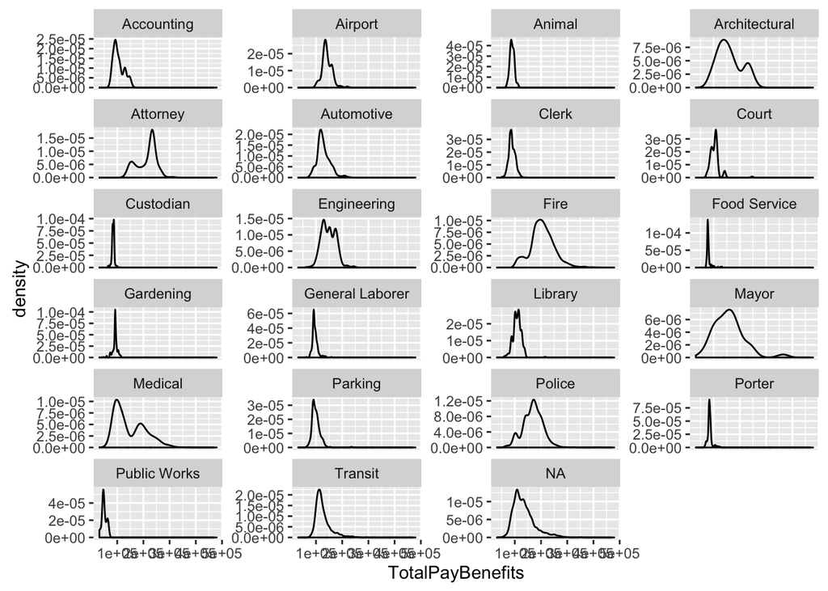

```r
ft %>%
    ggplot(aes(x = TotalPayBenefits)) +
    geom_density(alpha = 0.6) +
    facet_wrap(~JobType, scales = "free_y", ncol = 4)
```

Well, that’s a little interesting. Look at **Engineering** - is that 3 spikes? Also, steep ascent (looks like a minimum lower bound) as well as a pretty steep cliff at the high end.

Perhaps the City needs to compete with tech companies at the low end (lower bar), and then doesn’t compete at the higher end (so people leave?).

And look at **Attorney** - seems like a decent number start low, but most attorneys make the same amount of money.

**Medical** suggests there’s more going on, with such a clear indication of two underlying distributions.

Why don’t we take a closer look at **Medical**?

#### JobType Medical

We might as well look at a Mixture Model for this.

First of all, let’s take a closer look.

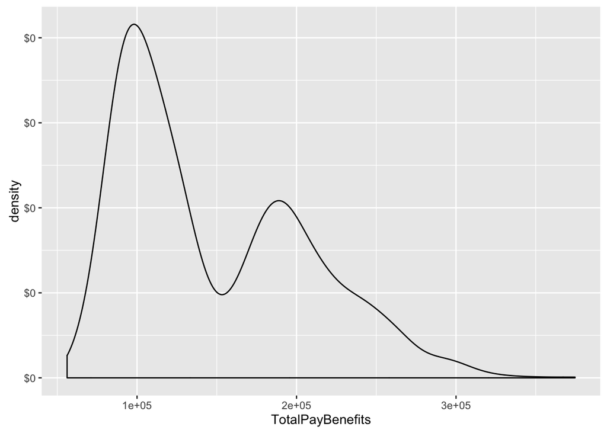

```r
ft %>%
    filter(JobType == "Medical") %>%
    ggplot(aes(x = TotalPayBenefits)) +
    geom_density() +
    scale_y_continuous(labels = dollar)
```

It looks like we have one peak around $100,000, and another just below $200,000.

Let’s figure out roughly what they could be…

```r
ft %>%
    filter(JobType == "Medical") %>%
    mutate(breaks = TotalPayBenefits > 150000) %>%
    group_by(breaks) %>%
    summarise(median = median(TotalPayBenefits),
              mean = mean(TotalPayBenefits),
              sd = sd(TotalPayBenefits))
```

```
## Source: local data frame [2 x 4]
##
##   breaks   median     mean       sd
## 1  FALSE 101800.9 104383.7 18060.62
## 2   TRUE 199648.4 209014.8 36480.80
```

Alright - let’s fit a mixture model.

```
## number of iterations= 39
```

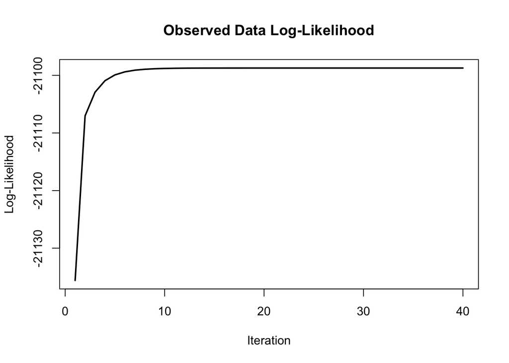

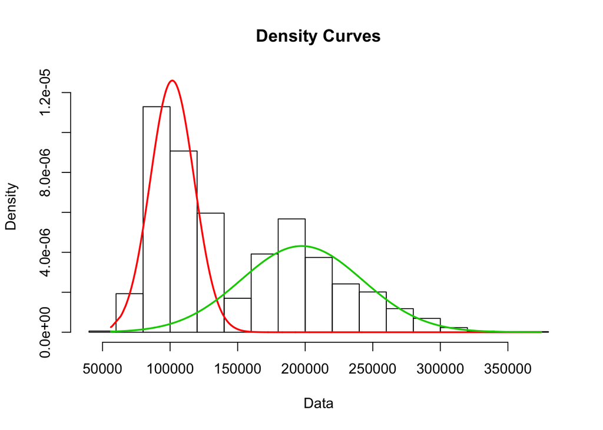

```r
medical <- filter(ft, JobType == "Medical")
normalmixEM(medical$TotalPayBenefits, lambda = .5,
            mu = c(104383, 209014), sigma = c(18060,36480)) %>%
    plot(density = T)
```

That doesn’t look unreasonable; though, of course, it’s hard to identify which jobs would be in each category (or what the categories are) without more work. It could also be very wrong (and likely is: the second bump is probably senior staff, supervisors, management, etc).

### Job Types

I suspect we can do a better job. I’m not going to, since I’m about done with the time I set aside to do this work, but let’s consider:

- Assistants
- Supervisors

Take Assistants -

```r
ft %>%
    mutate(Assistant = str_extract(JobTitle, "Asst|Assistant")) %>%
    group_by(Assistant) %>%
    summarise(mean(TotalPayBenefits))
```

```
## Source: local data frame [3 x 2]
##
##   Assistant mean(TotalPayBenefits)
## 1 Assistant               107119.7
## 2      Asst               139663.3
## 3        NA               140087.0
```

It looks like people who are called **Asst** tend to make more money. It turns out - great surprise! - that when the City shortens the word, it’s because it’s a long title. Often when **Manager** or **Supervisor** is after it.

```r
ft %>%
    mutate(Assistant = str_extract(JobTitle, "Asst|Assistant")) %>%
    filter(Assistant == "Asst") %>%
    group_by(JobTitle) %>%
    summarise(Frequency = n(), pay = mean(TotalPayBenefits), sd = sd(TotalPayBenefits)) %>%
    arrange(desc(Frequency))
```

```
## Source: local data frame [39 x 4]
##
##                         JobTitle Frequency       pay        sd
## 1                      Asst Engr       118 128483.16 11142.808
## 2  Electrl Trnst Mech, Asst Sprv        24 168606.85 28532.740
## 3    Electr Maint Tech Asst Sprv        16 176222.57 26874.701
## 4       Commercial Div Asst Sprv        15 124415.58  9200.351
## 5  Automotive Mechanic Asst Sprv        13 156475.80 12901.847
## 6     Asst Materials Coordinator        10 130569.66 15069.291
## 7       Auto Machinist Asst Sprv         8 146306.60 11535.430
## 8      Janitorial Svcs Asst Sprv         7 107686.22  4682.386
## 9    Aquatics Facility Asst Supv         6  80212.52  4338.544
## 10  Asst Chf of Dept (Fire Dept)         6 344702.51 33113.918
## ..                           ...       ...       ...       ...
```

The compensation looks to be all over the place. Hmm.

#### Word Compensation

What if we measured average compensation by word?

```r
words <- strsplit(tolower(ft$JobTitle), "\\W")
names(words) <- ft$Id

# Create tall matrix.
words_long <- data.frame(Id = names(unlist(words)),
                         Word = unlist(words),
                         stringsAsFactors = F)

# Strip off index position.
words_long <- words_long %>%
    mutate(Id = gsub("\\d$","", Id),
           Id = as.integer(Id))

ft_comp <- ft %>% select(Id, JobTitle, TotalPayBenefits)

words_long %>% left_join(ft_comp) ->
    words_salary
head(words_salary)
```

```
##       Id     Word          JobTitle TotalPayBenefits
## 1 110533     asst Asst Med Examiner         479652.2
## 2 110533      med Asst Med Examiner         479652.2
## 3 110533 examiner Asst Med Examiner         479652.2
## 4 110535    chief   Chief of Police         418019.2
## 5 110535       of   Chief of Police         418019.2
## 6 110535   police   Chief of Police         418019.2
```

OK, so just quickly - for every word that occurs at least twice, return the average.

```r
words_salary %>%
    group_by(Word) %>%
    summarise(Pay = mean(TotalPayBenefits, na.rm = T),
              sd = sd(TotalPayBenefits, na.rm = T),
              titles = n_distinct(JobTitle),
              people = n_distinct(Id)) %>%
    filter(people > 1, !is.na(Pay)) %>%
    mutate(Pay = dollar(Pay), sd = dollar(sd)) %>%
    arrange(desc(titles)) %>%
    head(20)
```

```
## Source: local data frame [20 x 5]
##
##            Word      Pay      sd titles people
## 1               $166,185 $58,521    112   1712
## 2             1 $121,585 $37,815     64    745
## 3    supervisor $138,983 $40,510     63    657
## 4        senior $121,492 $41,857     62   1441
## 5     assistant $107,120 $33,574     49   1052
## 6             2 $143,751 $44,308     46    993
## 7          sprv $150,370 $32,219     45    219
## 8          asst $139,663 $49,491     39    300
## 9        worker $107,262 $21,712     38   1613
## 10        clerk  $91,347 $11,182     36   1348
## 11    inspector $150,719 $37,548     31    396
## 12      manager $193,873 $35,052     31    834
## 13   technician $104,979 $16,656     30    289
## 14      analyst $129,870 $23,464     29    986
## 15      officer $154,815 $38,941     28   1955
## 16           sr $126,287 $35,327     26    755
## 17   specialist $159,184 $60,888     24    312
## 18        chief $239,636 $78,274     23    121
## 19 investigator $125,903 $23,174     23    153
## 20            3 $184,196 $44,254     22   1489
```

Alrighty then. Looks like there’s some information there.

Now - just for fun - what happens if we make a model? Let’s restruct to words that occur at least 20 times. We’ll miss some (like Mayor), but might get some interesting results.

```r
words_to_model <- words_salary %>%
    group_by(Word) %>%
    summarise(people = n_distinct(Id)) %>%
    filter(people >= 20)

words_model <- subset(words_salary, Word %in% words_to_model$Word)

model <- lm(TotalPayBenefits ~ Word, words_model)
model_summary = summary(model)
```

First of all, what’s our R squared as a base measure?

```r
model_summary$adj.r.squared
```

```
## [1] 0.5498879
```

That’s better than I expected!

So: what words are signifcant?

```r
coefficients = model_summary$coefficients
sig_coef = coefficients[coefficients[, 4] < 0.05, ]
# Fix the names
rownames(sig_coef) <- gsub("^Word", "", rownames(sig_coef))
sig_coef <- as.data.frame(sig_coef, row.names = rownames(sig_coef))
sig_coef$Word = rownames(sig_coef)
head(sig_coef)
```

```
##              Estimate Std. Error    t value      Pr(>|t|)        Word
## (Intercept) 166185.24   675.4123 246.050064  0.000000e+00 (Intercept)
## 1           -44600.50  1364.5801 -32.684415 4.246969e-232           1
## 2           -22433.85  1229.2106 -18.250617  3.379092e-74           2
## 3            18010.48  1076.8484  16.725175  1.224874e-62           3
## 4           -31355.26  3703.2858  -8.466875  2.581406e-17           4
## account     -75630.96  2375.1416 -31.842715 1.642006e-220     account
```

OK: the intercept is $166 - much higher than the actual average (~$130k)

What coefficients have the biggest negative effect?

```r
sig_coef %>%
    arrange(Estimate) %>%
    head
```

```
##     Estimate Std. Error   t value     Pr(>|t|)     Word
## 1 -106825.15   6382.832 -16.73633 1.016693e-62     prof
## 2 -106785.49   6781.963 -15.74551 9.744273e-56       ps
## 3 -104290.51   6153.299 -16.94871 2.858600e-64      svc
## 4 -101572.47  13229.578  -7.67768 1.646413e-14 gardener
## 5  -96204.86   6047.578 -15.90800 7.456517e-57       to
## 6  -93455.84   5851.757 -15.97056 2.752741e-57    cadet
```

What about the biggest positive effect?

```r
sig_coef %>%
    arrange(desc(Estimate)) %>%
    head
```

```
##    Estimate Std. Error   t value      Pr(>|t|)        Word
## 1 166185.24   675.4123 246.05006  0.000000e+00 (Intercept)
## 2 143055.81  5851.7574  24.44664 2.722922e-131   battalion
## 3 143055.81  5851.7574  24.44664 2.722922e-131    suppress
## 4 100978.20  5760.8354  17.52839  1.333673e-68        viii
## 5  94122.93  3926.6964  23.97000 2.524221e-126   physician
## 6  87385.24  3822.3221  22.86182 3.814475e-115        head
```

Battalion? Really?

```r
ft %>%
    filter(grepl("battalion", tolower(JobTitle)))
```

```
## Source: local data frame [31 x 13]
##
##        Id       EmployeeName                       JobTitle  BasePay
## 1  110540         Samson Lai Battalion Chief, Fire Suppress 179464.1
## 2  110546        Jose L Velo Battalion Chief, Fire Suppress 183333.8
## 3  110547 Bryan W Rubenstein Battalion Chief, Fire Suppress 177771.2
## 4  110565       Marty A Ross Battalion Chief, Fire Suppress 177771.1
## 5  110566     Lorrie A Kalos Battalion Chief, Fire Suppress 179464.2
## 6  110567      Khairul A Ali Battalion Chief, Fire Suppress 179464.2
## 7  110571    Victor H Wyrsch Battalion Chief, Fire Suppress 179464.2
## 8  110574      Kevin W Smith Battalion Chief, Fire Suppress 177722.5
## 9  110576  Kirk W Richardson Battalion Chief, Fire Suppress 179464.2
## 10 110579      Pete L Fay Jr Battalion Chief, Fire Suppress 179464.2
## ..    ...                ...                            ...      ...
## Variables not shown: OvertimePay (dbl), OtherPay (dbl), Benefits (dbl),
##   TotalPay (dbl), TotalPayBenefits (dbl), Year (int), Status (chr), level
##   (chr), JobType (chr)
```

Interesting - all inthe Fire Supress group I imagine that’s Fire Department.

# Conclusion

Well, that’s enough for now.

There are open challenges in:

- Classifying the JobsTitle.
- Classifying the EmployeeName (didn’t even touch that).
- Classifying the FTE Status of people not in 2014.
- Looking at Overtime / Other (also didn’t touch)